# HWS 5 – done

Jeffrey Walker

2022-10-17

# Setup and Import

The treatment factor has three levels

1. WT – A wild type strain of mouse. This is the control group.
2. MFS – A Marfan syndrome strain of mouse. This is a positive control. We expect to see increased acta2 expression in this group.
3. KT5823 – The Marfan syndrome strain treated with KT5823, a molecule that inhibits PRKG. If the researchers hypothesis that “Marfan syndrome is caused by overactivation of sGC-PRKG signaling” is correct, and this signaling in the Marfan strain is overactive, then acta2 expression in the KT5823 group should be less than in the MFS group.

Modeling strategy.

1. Unless model checking show really poor approximation, use general linear model.
2. Given hypothesis, we want WT to be the reference level (it is the control) and we want MFS to be in position 2 (its acting as another control). We want our contrasts to be in the direction of KT5823 - WT and KT5823 - MFS.
3. Examine and report on contrasts
- The focal contrast: KT5823 - MFS – what is effect of KT5823 in marfan mice?
- secondary contrast: MFS - WT: did positive control respond as expected?
- tertiary contrast: KT5823 - WT: gives us a sense of the magnitude of rescue effect of kt5823.

```r
data_from <- "Aortic disease in Marfan syndrome is caused by overactivation of sGC-PRKG signaling by NO"
data_file <- "Aortic-disease-fig2d-2021.xlsx"
file_path <- here(data_folder, data_from, data_file)

fig2d <- read_excel(file_path) |>
  clean_names() |>
  data.table()

# make WT the reference and MFS the 2nd control, so position two
treatment_levels <- c("WT", "MFS", "KT5823")
fig2d[, treatment := factor(treatment,
                            levels = treatment_levels)]
```

# Part I

1. Examine

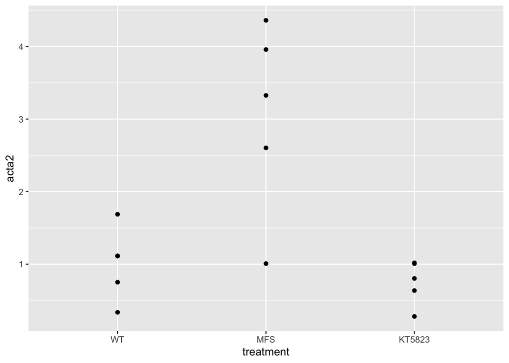

```r
qplot(x = treatment, y = acta2, data = fig2d)
```

No obvious impossible data. The sample size is small so cannot really eyeball assumptions. Stick with default linear model.

2. Fit the model

```r
m1 <- lm(acta2 ~ treatment, data = fig2d)
```

3. Check the model

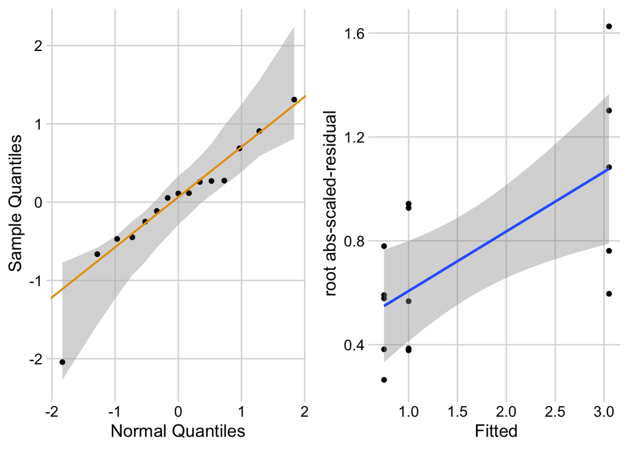

```r
ggcheck_the_model(m1)
```

data look like they are sampled from normal but some evidence of mean-variance relationship. Could use a glm but to keep-it-simple, stay with linear model, probably without large risk

4. Inference

```r
m1_coef <- cbind(coef(summary(m1)),
                 confint(m1))
m1_emm <- emmeans(m1, specs = "treatment")
m1_pairs <- contrast(m1_emm,
                     method = "revpairwise", # direction specified
                     adjust = "none") |> # specific contrasts
  summary(infer = TRUE)
```

Notes

1. the arguments for contrast function, including “adjust =”, are in [10.2.4 Using the contrast function](https://www.middleprofessor.com/files/bio413/applied_biostatistics/oneway.html#using-the-contrast-function)
2. the concept of planned contrasts, as opposed to comparing all pairwise contrasts, is in [10.2.4.3 Planned comparisons using custom contrasts](https://www.middleprofessor.com/files/bio413/applied_biostatistics/oneway.html#planned-comparisons-using-custom-contrasts)
3. There are some more comments in [15.8.3 Adjusting p-values for multiple tests](https://www.middleprofessor.com/files/bio413/applied_biostatistics/factorial.html#twoway-multiple-tests)
4. Ugg – I didn’t really flesh that out as much as I did in class today so I need to go back and update the text here.

```r
m1_coef |>
  kable(digits = c(2,3,1,4,2,2)) |>
  kable_styling()
```

|  | Estimate | Std. Error | t value | Pr(>\|t\|) | 2.5 % | 97.5 % |
| --- | --- | --- | --- | --- | --- | --- |
| (Intercept) | 1.00 | 0.374 | 2.7 | 0.0201 | 0.19 | 1.81 |
| treatmentMFS | 2.05 | 0.528 | 3.9 | 0.0022 | 0.90 | 3.20 |
| treatmentKT5823 | -0.25 | 0.528 | -0.5 | 0.6428 | -1.40 | 0.90 |

This is for completeness. Interpret using contrast table

```r
m1_pairs |>
  kable(digits = c(1,2,3,1,3,3,2,4)) |>
  kable_styling()
```

| contrast | estimate | SE | df | lower.CL | upper.CL | t.ratio | p.value |
| --- | --- | --- | --- | --- | --- | --- | --- |
| MFS - WT | 2.05 | 0.528 | 12 | 0.900 | 3.202 | 3.88 | 0.0022 |
| KT5823 - WT | -0.25 | 0.528 | 12 | -1.402 | 0.900 | -0.48 | 0.6428 |
| KT5823 - MFS | -2.30 | 0.528 | 12 | -3.454 | -1.152 | -4.36 | 0.0009 |

Contrasts * Focal contrast (KT5823 - MFS): expected direction of kt5823 effect * 2nd contrast (MFS - WT): expected direction of MFS effect * 3rd contrast (KT5823 - WT): consistent with full rescue (inactivation of sGC-PRKG signaling)

5. Figure

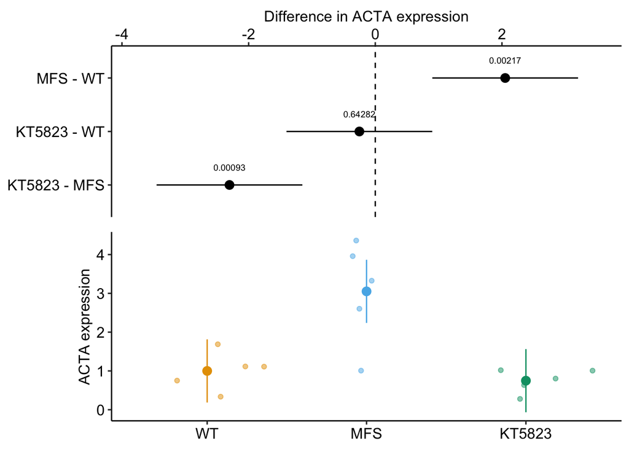

```r
ggplot_the_model(m1,
                 m1_emm,
                 m1_pairs,
                 y_label = "ACTA expression",
                 effect_label = "Difference in ACTA expression")
```

Traditional plot

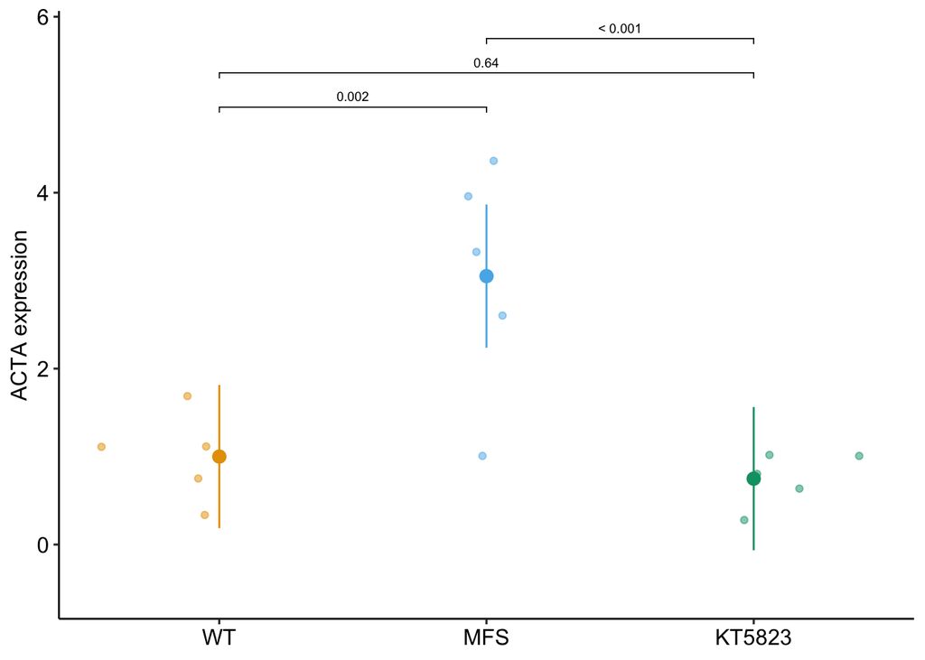

```r
ggplot_the_response(m1,
                 m1_emm,
                 m1_pairs,
                 y_label = "ACTA expression")
```

6. Report

MFS mice treated with KT5823 had lower *acta* expression levels than MFS mice without KT5823 (KT5823 - MFS effect: -2.303; CI: -3.45, -1.15l; p = 0.0009).

# Part II

```r
fig2d_ss <- fig2d[treatment != "WT"]
subset_lm <- lm(acta2 ~ treatment, data = fig2d_ss)
coef(summary(subset_lm))
```

```
##                  Estimate Std. Error   t value     Pr(>|t|)
## (Intercept)      3.051340  0.4292333  7.108815 0.0001011094
## treatmentKT5823 -2.302626  0.6070275 -3.793280 0.0052870455
```

```r
subset_t <- t.test(acta2 ~ treatment,
                   var.equal = TRUE,
                   data = fig2d_ss)
subset_t
```

```
##
##  Two Sample t-test
##
## data:  acta2 by treatment
## t = 3.7933, df = 8, p-value = 0.005287
## alternative hypothesis: true difference in means between group MFS and group KT5823 is not equal to 0
## 95 percent confidence interval:
##  0.9028175 3.7024335
## sample estimates:
##    mean in group MFS mean in group KT5823
##            3.0513399            0.7487144
```

5. pvalue from original lm: 0.0009 p-value from subsetted lm: 0.005287 p-value from t-test: 0.005287

Why does that from the full data differ from the partial data? The p-value is a function of the t-value, which is the effect/SE. The SE is computed from the model $\sigma^2$ (modeled error variance). The model $\sigma^2$ is the estimate of the true variance of the distribution of the error (the residuals). With the full data, this modeled variance is estimated using three samples (WT, MFS, KT5823). With the subsetted data, used for both the lm and the t-test, this modeled variance is estimated from two samples (MFS, KT5823). So the modeled variance is different. The estimate using three samples is better than that for using two samples in the sense that there is less sampling error of the standard deviation (the standard error of the model standard error!). So over the long run, if there is an effect, the linear model with all groups will have higher power than a series of separate t-tests.

A simulation to show this:

```r
n_sim <- 10000
beta_1 <- 1
n <- 10
groups <- c("cn", "ko", "ko_drug")
fd <- data.table(
  treatment = rep(groups, each = n)
)
mu <- rep(c(0, beta_1, 0), each = n)
lm.p <- numeric(n_sim)
t.p <- numeric(n_sim)
for(i in 1:n_sim){
  fd[, y := rnorm(n*3, mean = mu, sd = 1)]
  m1 <- lm(y ~ treatment, data = fd)
  lm.p[i] <- coef(summary(m1))["treatmentko", "Pr(>|t|)"]
  t.p[i] <- t.test(y ~ treatment, data = fd[treatment != "ko_drug"])$p.value
}

data.table(
  Method = c("lm", "t-test"),
  Power = c(sum(lm.p < 0.05)/n_sim,
            sum(t.p < 0.05)/n_sim)
)
```

```
##    Method  Power
## 1:     lm 0.5769
## 2: t-test 0.5562
```

Same simulation but with 10 groups (should be even higher power)

```r
n_sim <- 10000
beta_1 <- 1
n <- 10
groups <- c("cn", "ko", "ko_drug1", "ko_drug2", "ko_drug3", "ko_drug4", "ko_drug5", "ko_drug6", "ko_drug7", "ko_drug8")
n_groups <- length(groups)
fd <- data.table(
  treatment = rep(groups, each = n)
)
mu <- rep(c(0, beta_1, 0), each = n)
lm.p <- numeric(n_sim)
t.p <- numeric(n_sim)
for(i in 1:n_sim){
  fd[, y := rnorm(n*n_groups, mean = mu, sd = 1)]
  m1 <- lm(y ~ treatment, data = fd)
  lm.p[i] <- coef(summary(m1))["treatmentko", "Pr(>|t|)"]
  t.p[i] <- t.test(y ~ treatment, data = fd[treatment == "cn" | treatment == "ko"])$p.value
}

data.table(
  Method = c("lm", "t-test"),
  Power = c(sum(lm.p < 0.05)/n_sim,
            sum(t.p < 0.05)/n_sim)
)
```

```
##    Method  Power
## 1:     lm 0.6011
## 2: t-test 0.5609
```